# A4 Task2 Exploratory Report

Caitie Reza

11/18/2020

### Introduction

In this document, I will be using data from the Bonanza Creek Experimental Forest Long Term Ecological Research (LTER) site to explore the counts and sizes of juvenile snowshoe hares, *Lepus americanus*.

### Data Analysis

The snowshoe hare data, here named bonanza_hares.csv, is a collection of morphological and population data collected by Knut Keilland, F. Stuart Chapin, Roger Ruess, and Bjorn Flora from 1998 - 2012 at the Bonanza Creek Experimental Forest LTER (see citation below). The dataset consists of *Lepus americanus* sex, age, weight, limb measurements, and individual identification (right and left ear tag) information. Trap data was used from 3 study sites characterized by habitat type and disturbance level, including bonbs (Bonanza Black Spruce), bonmat (Bonanza mature), and bonrip (Bonanza Riparian).

Kielland, K., F.S. Chapin, R.W. Ruess, and Bonanza Creek LTER. 2017. Snowshoe hare physical data in Bonanza Creek Experimental Forest: 1999-Present ver 22. Environmental Data Initiative.

### Exploratory Findings

##### Read In

Before doing anything else, I will read in the snowshoe hare data (bonanza_hares.csv)

```r
hare_data <- read_csv(here("data", "bonanza_hares.csv"))
```

#### i) Annual Juvenile Hare Trap Counts

Here, I will make a subgroup showing year and juvenile hare trap counts called “annual_traps”. First, I’ll need to only keep observations for juvenile hares, or the “j” entries in the age column. Then, I’ll reformat the dates using the date() function of lubridate.

Then, I’ll create a figure plotting trap counts by year.

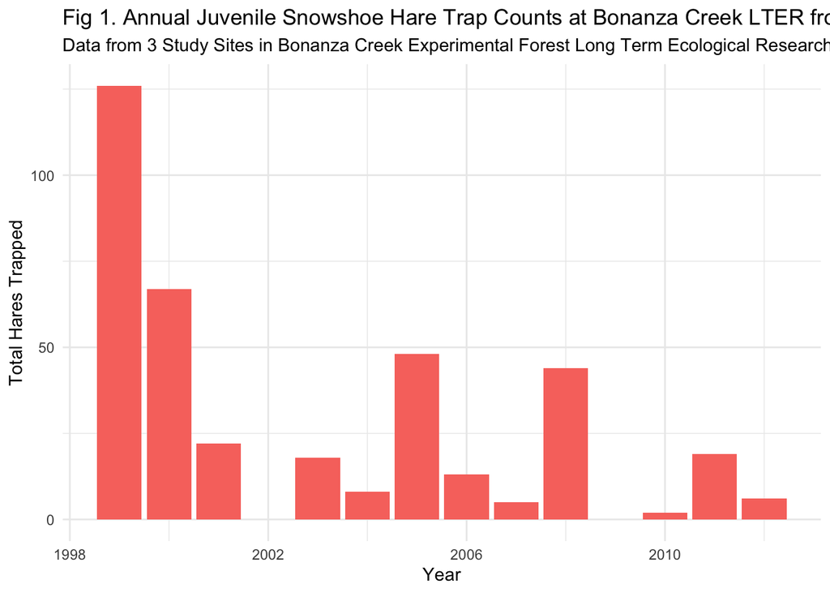

```r
annual_traps <- hare_data %>%
  filter(age == "j") %>%
  mutate("date_new" = mdy(date),
         "year" = year(date_new)) %>%
  group_by(year) %>%
  count()

ggplot(data = annual_traps, aes(x = year, y = n, fill = "salmon")) + geom_col(position = "dodge") +
  theme_minimal() +
  labs(x = "Year", y = "Total Hares Trapped",
       title = "Fig 1. Annual Juvenile Snowshoe Hare Trap Counts at Bonanza Creek LTER from 1999 - 2012",
       subtitle = "Data from 3 Study Sites in Bonanza Creek Experimental Forest Long Term Ecological Research Site (Kielland, K. et. al, 2017) ",
       fill = "Study Site") +
  theme(legend.position = "none")
```

### Visualizing Hare Weights

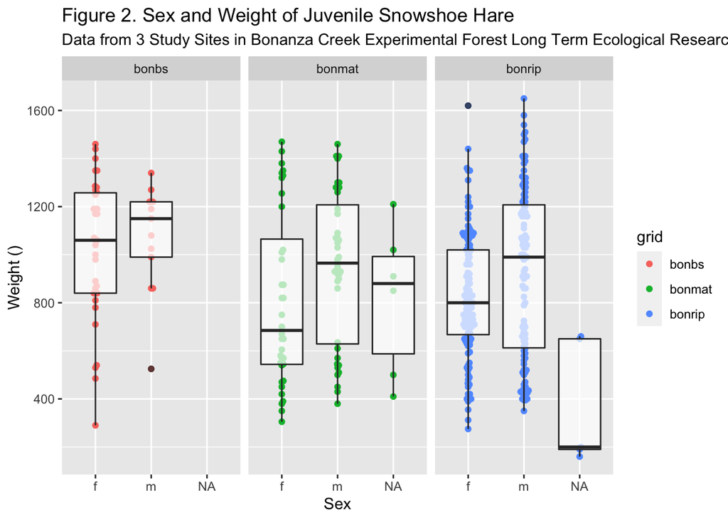

```r
sex_weight <- hare_data %>%
  filter(age == "j") %>%
  select(sex, age, weight, grid)


ggplot(data = sex_weight, aes(x = sex, y = weight)) +
  geom_beeswarm(aes(color = grid)) +
  facet_wrap(~grid) +
  geom_boxplot(alpha = .7) +
  labs(x = "Sex", y = "Weight ()",
       title = "Figure 2. Sex and Weight of Juvenile Snowshoe Hare",
       subtitle = "Data from 3 Study Sites in Bonanza Creek Experimental Forest Long Term Ecological Research Site (Kielland, K. et. al, 2017)")
```

###### **Figure 2.** This figure shows the relationship between the weight and sex of juvenile snowshoe trapped at three Bonanza Creek LTER study sites from 1998 - 2012.

##### Figure 2. Takeaways